# Exploratory Data Analysis for the Development of a Predictive Language Model

Jens Hooge

20.03.2016

# Background

The goal of this analysis is to give a brief overview over the data used in building a predictive language model. In this case we will be using three different text corpi, consisting of twitter, blog and news posts, thereby restricting ourselves on english texts. To form valid input for a prediction algorithm, the most widespread representation are frequency based n-grams. In the fields of computational linguistics and probability, an n-gram is a contiguous sequence of n items from a given sequence of text or speech. An n-gram of size 1 is referred to as a “unigram”; size 2 is a “bigram” (or, less commonly, a “digram”); size 3 is a “trigram”. Larger sizes are sometimes referred to by the value of n, e.g., “four-gram”, “five-gram”, and so on. In our case an n-gram consists of a sequence of n words and a corpus will be represented in a data structure, called term-document matrix. A mathematical matrix that describes the frequency of terms that occur in a collection of documents. In a term-document matrix, columns correspond to documents in the collection and rows correspond to terms. There are various schemes for determining the value that each entry in the matrix should take. In our case the entries consist of the absolute frequency of terms within each text corpus and will serve as the input for our predictive language model.

## Features of the input data

First we will give an overview of the original input data, which includes file size, word and line counts.

```
##                file   size   lines    words
## 1   en_US.blogs.txt 210 MB  899288 37334114
## 2    en_US.news.txt 210 MB 1010242 34365936
## 3 en_US.twitter.txt 160 MB 2360148 30341028
```

We can see that the the dataset requires about 580 MB and is balanced around the 30-37 million words. The number of lines differ between 900000 words for the blog corpus and about 2 million words. This is not surprising as the number of words for a tweet is limited to 140 characters and therefore consists of significantly less words, than the average blog or news post. Even though the file sizes do not seem to be very large, representing them in a corpus term-document matrix can be demanding on RAM.

For a proof of concept we therefore have randomly sampled 50000 lines of blogs and news data and 150000 lines of twitter data.

```
##                file  size  lines   words
## 1   en_US.blogs.txt 12 MB  50000 2064541
## 2    en_US.news.txt 10 MB  50000 1700165
## 3 en_US.twitter.txt 10 MB 150000 1930854
```

# Summary Statistics

## Unigrams

```
##  en_US.blogs.txt    en_US.news.txt     en_US.twitter.txt
##  Min.   :    1.00   Min.   :    1.00   Min.   :   1.00
##  1st Qu.:    3.00   1st Qu.:    2.00   1st Qu.:   2.00
##  Median :    7.00   Median :    7.00   Median :   5.00
##  Mean   :   39.58   Mean   :   35.57   Mean   :  38.59
##  3rd Qu.:   22.00   3rd Qu.:   21.00   3rd Qu.:  16.00
##  Max.   :10707.00   Max.   :12594.00   Max.   :9548.00
```

## Bigrams

```
##  en_US.blogs.txt    en_US.news.txt    en_US.twitter.txt
##  Min.   :   0.000   Min.   :  0.000   Min.   :   0.000
##  1st Qu.:   1.000   1st Qu.:  0.000   1st Qu.:   0.000
##  Median :   1.000   Median :  1.000   Median :   1.000
##  Mean   :   2.299   Mean   :  1.617   Mean   :   2.334
##  3rd Qu.:   2.000   3rd Qu.:  1.000   3rd Qu.:   2.000
##  Max.   :1318.000   Max.   :688.000   Max.   :2017.000
```

## Three-grams

```
##  en_US.blogs.txt   en_US.news.txt    en_US.twitter.txt
##  Min.   :  1.000   Min.   :  1.000   Min.   :  1.000
##  1st Qu.:  1.000   1st Qu.:  1.000   1st Qu.:  1.000
##  Median :  2.000   Median :  1.000   Median :  2.000
##  Mean   :  3.877   Mean   :  2.139   Mean   :  4.096
##  3rd Qu.:  4.000   3rd Qu.:  2.000   3rd Qu.:  4.000
##  Max.   :188.000   Max.   :104.000   Max.   :239.000
```

## Four-grams

```
##  en_US.blogs.txt  en_US.news.txt   en_US.twitter.txt
##  Min.   : 1.000   Min.   : 1.000   Min.   : 1.000
##  1st Qu.: 1.000   1st Qu.: 1.000   1st Qu.: 1.000
##  Median : 2.000   Median : 1.000   Median : 1.000
##  Mean   : 2.687   Mean   : 1.744   Mean   : 2.692
##  3rd Qu.: 3.000   3rd Qu.: 2.000   3rd Qu.: 3.000
##  Max.   :36.000   Max.   :18.000   Max.   :46.000
```

Non surprisingly, the maximum number of n-gram occurances decreases for larger sequences. On the other hand the average number of occurances for Bi, 3- and 4-grams show no downward trend, which is unexpected. The above statistics however does not give any information which of the n-grams are more represented in the different corpi. The 15 most frequent n-grams can be seen in the following figures.

## Twitter n-gram Statistics

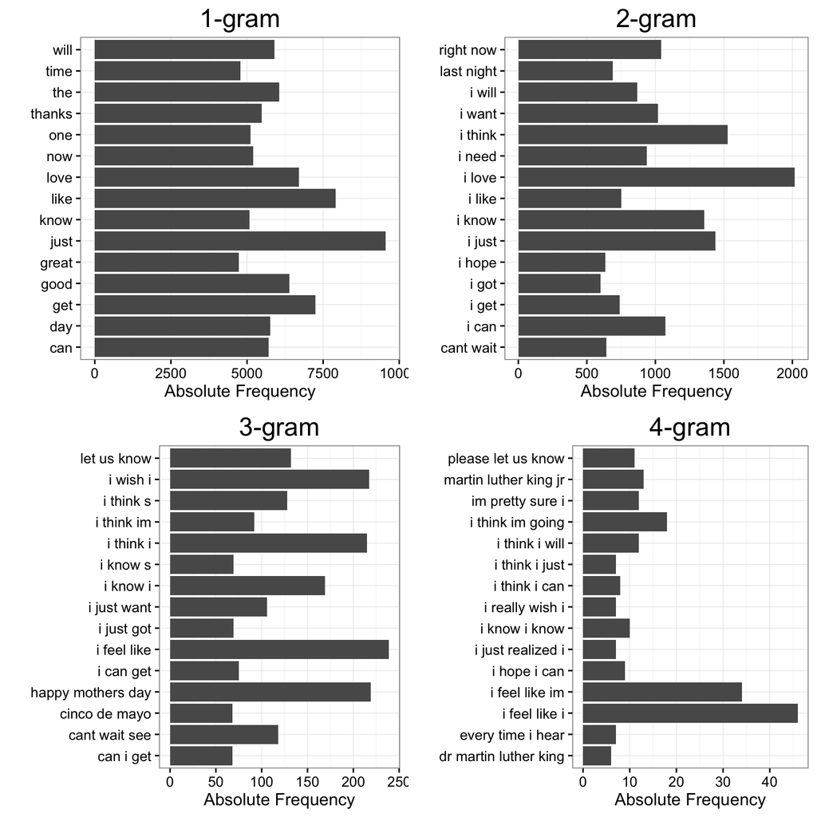

## Blog n-gram Statistics

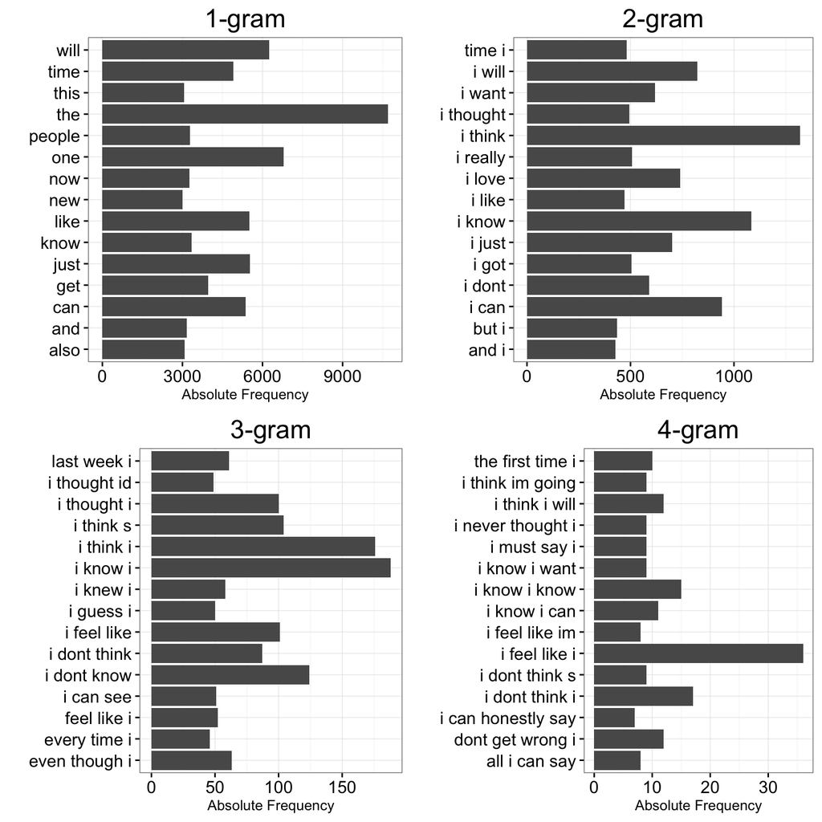